# Dataset Builder

Greg Macfarlane

1/20/2020

Constructing a PopulationSim implementation is not a trivial task. In this document, we guide the users through constructing a basic PopulationSim scenario.

PopulationSim allows users to create controls at multiple levels. In this case we are going to create three levels of controls:

1. Region-wide: total population
2. Tract-level: household size and income, and person age
3. TAZ level: number of households

We are going to build this synthetic population for Provo and Orem, Utah. This involves the PUMAs `49002` and `49003`. We can get the census tracts these PUMAs contain from the Census Bureau’s Tract / PUMA lookup file.

```r
puma_url <- "https://www2.census.gov/geo/docs/maps-data/data/rel/2010_Census_Tract_to_2010_PUMA.txt"
puma_tract <- read_csv(puma_url, col_types = list(PUMA5CE = col_character())) %>%
  transmute(
    TRACT = str_c(STATEFP, COUNTYFP, TRACTCE),
    PUMA = PUMA5CE
  ) %>%
  filter(PUMA %in% c("49002", "49003"))
```

We also want to get the geographic boundaries layer for these tracts. We get this directly from the Census.

```r
tr <- tracts("UT", county = unique(substr(puma_tract$TRACT, 3, 5)),
             class = "sf", progress_bar = FALSE) %>%
  st_transform(4326) %>%
  transmute(GEOID) %>%
  left_join(puma_tract, by = c("GEOID" = "TRACT")) %>%
  filter(!is.na(PUMA))
```

The last step we need is the list of TAZs that intersect with these tracts. We use a TAZ file obtained from the Mountainland Association of Government travel model. We filter the tracts based on whether they intersect.

```r
taz <- st_read("inputs/taz.geojson") %>%
  mutate(TAZ = as.character(TAZID)) %>%
  # remove external stations
  filter(CO_FIPS > 0) %>%
  select(TAZ) %>%

  # remove taz that do not map to a tract
  st_join(tr) %>% filter(!is.na(PUMA)) %>%

  # remove duplicates of TAZ that map to many tracts
  group_by(TAZ) %>% slice(1) %>% ungroup()
```

```
## although coordinates are longitude/latitude, st_intersects assumes that they are planar
```

The map below shows the TAZ and Tract boundaries for our controls. As the map shows, there is not a perfect correlation between the boundaries of the TAZ and tract layers. Nevertheless to make the geographic crosswalk we will use the simplifying assumption that each TAZ belongs to the tract that contains the TAZ centroid. The TAZ covering Utah Lake will be removed when we do this.

```r
leaflet() %>%
  addProviderTiles(providers$Esri.WorldGrayCanvas) %>%
  addPolygons(data = tr, group = "Tract", color = "blue") %>%
  addPolygons(data = taz, group = "TAZ", color = "red") %>%
  addLayersControl(overlayGroups = c("Tract", "TAZ"))
```

[interactive chart not shown]

## Geographic Cross-walk

To make the crosswalk we locate the taz centroids within each tract, and then append the PUMA, county, and region codes. The plot below visualizes these points as well as the TAZ, tract, and PUMA ids. The resulting table is the geographic crosswalk required by PopulationSim.

```r
crosswalk <- taz %>%
  # determine which tract the taz is in
  select(TAZ) %>% st_centroid() %>%
  st_join(tr, st_within) %>% filter(!is.na(GEOID)) %>%
  # fill out remainder of columns
  rename(TRACT = GEOID) %>% mutate(REGION = "1")
```

```
## although coordinates are longitude/latitude, st_within assumes that they are planar
```

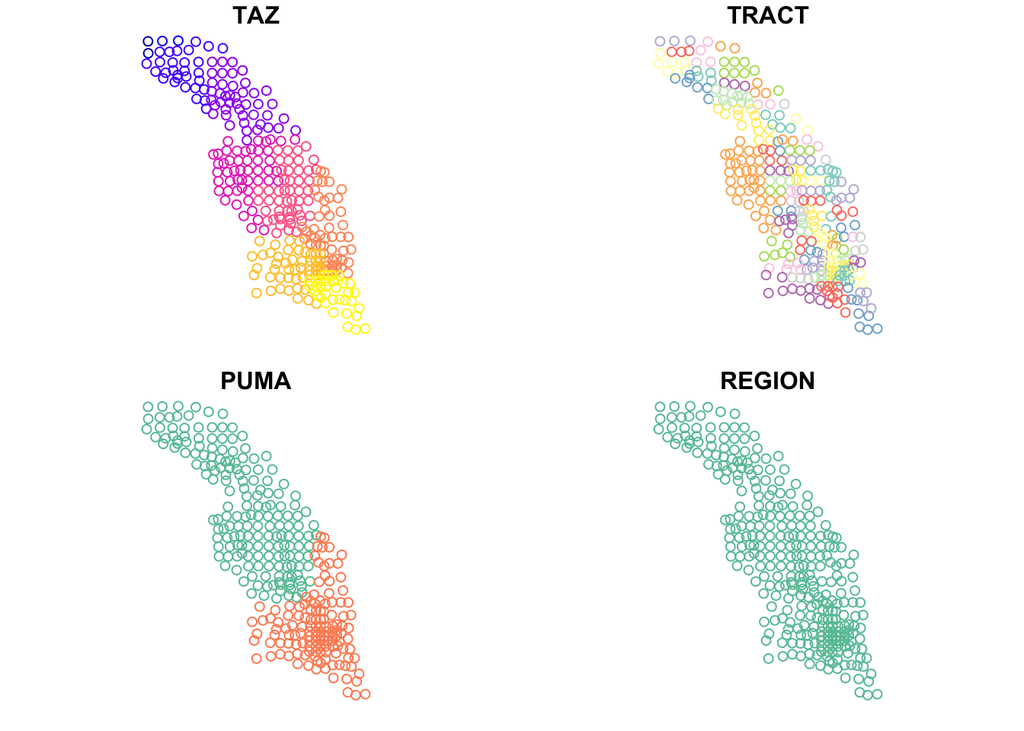

```r
plot(crosswalk %>% mutate(TAZ = as.numeric(TAZ)))
```

```r
(crosswalk <- crosswalk %>% st_set_geometry(NULL) %>% as_tibble())
```

```
## # A tibble: 312 x 4
##    TAZ   TRACT       PUMA  REGION
##    <chr> <chr>       <chr> <chr>
##  1 2057  49049000204 49002 1
##  2 2059  49049000205 49002 1
##  3 2149  49049000205 49002 1
##  4 2150  49049000205 49002 1
##  5 2151  49049000206 49002 1
##  6 2152  49049000206 49002 1
##  7 2153  49049000206 49002 1
##  8 2154  49049010700 49002 1
##  9 2164  49049010700 49002 1
## 10 2165  49049010213 49002 1
## # … with 302 more rows
```

## Controls

Attributes we want to control for include: - Number of households - Household size - Household income - Age of persons - Household workers - Person worker status

### TAZ-level controls

The only TAZ-level control we get from WFRC is the number of households in each TAZ. Therefore, this will be the only control in this file. The MAG data is only available for 2020, so that’s what we will be using even if 2017 or 2018 might be more appropriate. We filter the list of controls to the TAZ that we are getting in the crosswalk. We need to ensure that the TAZ code is a character string and the household target is an integer.

```r
# read socioeconomic data file
(taz_control <- read_csv("inputs/SE_MAG_2020.csv") %>%
  transmute(TAZ = as.character(TAZID), HHBASE = as.integer(ceiling(TOTHH))) %>%
  filter(TAZ %in% crosswalk$TAZ))
```

```
## # A tibble: 312 x 2
##    TAZ   HHBASE
##    <chr>  <int>
##  1 2057     336
##  2 2059     218
##  3 2149     470
##  4 2150     335
##  5 2151     473
##  6 2152     285
##  7 2153     285
##  8 2154     295
##  9 2164      84
## 10 2165     505
## # … with 302 more rows
```

### Tract-Level Controls

The attributes available from the ACS include the following: - Household size, derived from Table `B08202: HOUSEHOLD SIZE BY NUMBER OF WORKERS IN HOUSEHOLD` - Household workers, derived from the same table - Age, derived from Table `B01001: SEX BY AGE` - Income, derived from Table `B19001:HOUSEHOLD INCOME IN THE PAST 12 MONTHS (IN 2018 INFLATION-ADJUSTED DOLLARS)`

First, we can collect a unique list of all the tracts we want to get controls for, alongside a complete list of all ACS variables

```r
mytracts <- unique(crosswalk$TRACT)
mycounties <- unique(substr(crosswalk$TRACT, 3, 5))
acsvars <- load_variables(2018, "acs5", cache = TRUE)
```

#### Household size and workers

Because these two values come in the same table, we will build them together. In both cases the top-line category contains all households with that many workers / persons or more.

```r
swvars <- str_c("B08202_", sprintf("%03d", c(2:5, 6, 9, 13, 18)))
raw_sw <- get_acs("tract", variables = swvars, state = "UT", county = mycounties)
size_work <- raw_sw %>%
  left_join(acsvars, by = c("variable" = "name")) %>%
  separate(label, c("VAR", "total", "label"), sep = "!!") %>%
  select(GEOID, label, estimate)

works <- size_work %>%
  filter(grepl("work", label)) %>%
  mutate(
    num_work = str_extract(label, "\\d+"),
    workcat = case_when(
      num_work == 1 ~ "HHWORK1",
      num_work == 2 ~ "HHWORK2",
      num_work == 3 ~ "HHWORK3",
      TRUE ~ "HHWORK0"
    )
  ) %>%
  group_by(GEOID, workcat) %>% summarize(count = as.integer(sum(estimate)))

sizes <- size_work %>%
  filter(!grepl("work", label)) %>%
  mutate(
   num_size = str_extract(label, "\\d+"),
   sizecat = str_c("HHSIZE", num_size)
  ) %>%
  group_by(GEOID, sizecat) %>% summarize(count = as.integer(sum(estimate)))
```

#### Age

This is the number of people in each age category.

```r
agevars <- str_c("B01001_", sprintf("%03d", c(3:25, 27:49)))
raw_ages <- get_acs("tract", variables = agevars, state = "UT", county = mycounties)
ages <- raw_ages %>%
  left_join(acsvars, by = c("variable" = "name")) %>%
  separate(label, c("VAR", "total", "sex", "age"), sep = "!!") %>%
  select(GEOID, sex, age, estimate)  %>%

  # regroup age categories
  mutate(
    numage = as.numeric(substr(age, 1, 2)),
    agecat = case_when(
      numage %in% c(15:24) ~ "PAGE1",
      numage %in% c(25:54) ~ "PAGE2",
      numage %in% c(55:64) ~ "PAGE3",
      numage %in% c(65:99) ~ "PAGE4",
      TRUE ~ "PAGE0" # children less than 15 not categorized in demo
    )
  ) %>%

  # consolidate men and women
  group_by(GEOID, agecat) %>%
  summarise(count = as.integer(sum(estimate)))
```

#### Income

This is the household income variable, which is categorized as follows: - <$15k - $15k - $30k - $30k - $60k - > $60k

```r
incvars <- str_c("B19001_", sprintf("%03d", c(2:17)))
raw_incs <- get_acs("tract", variables = incvars, state = "UT", county = mycounties)
incs <- raw_incs %>%
  left_join(acsvars, by = c("variable" = "name")) %>%
  separate(label, c("VAR", "total", "income"), sep = "!!") %>%
  select(GEOID, income, estimate)  %>%
  # regroup income categories
  mutate(
    numinc  = stringr::str_extract(income, "\\d+"),
    inccat = case_when(
      numinc <  15 ~ "HHINC1",
      numinc <  30 ~ "HHINC2",
      numinc <  60 ~ "HHINC3",
      numinc >= 60 ~ "HHINC4",
      TRUE ~ as.character(NA)
    )
  ) %>%
  group_by(GEOID, inccat) %>%
  summarise(count = as.integer(sum(estimate)))
```

#### Tract Controls File

When all of the controls have been gathered, we can put them into one large table.

```r
(tract_controls <- tibble(TRACT = mytracts) %>%
   left_join(ages  %>% spread(agecat,  count), by = c("TRACT" = "GEOID")) %>%
   left_join(incs  %>% spread(inccat,  count), by = c("TRACT" = "GEOID")) %>%
   left_join(works %>% spread(workcat, count), by = c("TRACT" = "GEOID")) %>%
   left_join(sizes %>% spread(sizecat, count), by = c("TRACT" = "GEOID"))
)
```

```
## # A tibble: 68 x 18
##    TRACT PAGE0 PAGE1 PAGE2 PAGE3 PAGE4 HHINC1 HHINC2 HHINC3 HHINC4 HHWORK0
##    <chr> <int> <int> <int> <int> <int>  <int>  <int>  <int>  <int>   <int>
##  1 4904…  2015   975  2371   568   539    468    341    589    406     301
##  2 4904…  1308   627  1344   247   226    253    175    120    354     111
##  3 4904…  1205   506  1231   309   345    266    152    178    288     121
##  4 4904…  1388   861  1609   643   730    342    248    308    518     283
##  5 4904…  1095   534   926   190   237    127    279     71    157      70
##  6 4904…  1177   786  1712   301   578    438    322    448    276     341
##  7 4904…  1222   704  1535   226   296    245    116    411    413     234
##  8 4904…  1755   833  2811   325   557    637    425    880    490     348
##  9 4904…  1167   633  1163   332   230    254    138    262    256     136
## 10 4904…  2918  1787  2642   693   573    546    443    361    702     312
## # … with 58 more rows, and 7 more variables: HHWORK1 <int>, HHWORK2 <int>,
## #   HHWORK3 <int>, HHSIZE1 <int>, HHSIZE2 <int>, HHSIZE3 <int>,
## #   HHSIZE4 <int>
```

### Meta Controls

PopulationSim requires (we think) at least some region-level controls. We will simply sum up the total population in the controls data to work with this.

```r
(meta <- tract_controls %>%
  summarise(
    REGION = 1,
    totalPOP = sum(PAGE0) +  sum(PAGE1) +  sum(PAGE2) +
      sum(PAGE3) +  sum(PAGE4)))
```

```
## # A tibble: 1 x 2
##   REGION totalPOP
##    <dbl>    <int>
## 1      1   289742
```

## PUMS Seed Data

The uncompressed seed data is too large to commit, so we have committed compressed versions of the original files. We need to clean and re-save the PUMS seed data files for households and for people. In the case of households, this entails filtering the households without people, and replacing `NA` values in the controls with other values.

```r
# read in pums HH file, specifying datatypes for key columns
pums_hh <- read_csv(
  "inputs/psam_h49.csv.zip",
  col_types = list(SERIALNO = col_character(), NP = col_integer(),
                   FINCP = col_number(), ADJINC = col_number(),
                   WGTP = col_number())
)

#' A function to replace NA values with non-missing stupid numbers
replace_na <- function(x) {
  ifelse(is.na(x),-8,x)
}

seed_hh <- pums_hh %>%
  # remove empty households
  filter(NP > 0) %>% filter(WGTP > 0) %>%
  # remove households from outside the region
  filter(PUMA %in% crosswalk$PUMA) %>%
  mutate(
    # create unique hh_id field
    hh_id = 1:nrow(.),
    # compute adjusted numeric income
    HHINCADJ = FINCP * ADJINC
  ) %>%
  # apply replacement function to key variables
  mutate_at(.vars = vars(NP, WIF, WGTP, HHINCADJ), replace_na)
```

```r
pums_persons <- read_csv(
  "inputs/psam_p49.csv.zip",
  col_types = list(SERIALNO = col_character(), PWGTP = col_number())
)

seed_per <- pums_persons %>%
  # join hhid field, and only keep households we filtered down to.
  inner_join(seed_hh %>% select(SERIALNO, hh_id, WGTP)) %>%
  # replace NA values with something less stupid
  mutate_at(.vars = vars(PWGTP, AGEP), replace_na)
```

## Write out to files

With all of the data compiled, we now write out the files to the `data/` folder

```r
# Controls
write_csv(meta, "data/control_totals_meta.csv")
write_csv(tract_controls, "data/control_totals_tract.csv")
write_csv(taz_control, "data/control_totals_taz.csv")

# Seed
write_csv(seed_hh, "data/seed_households.csv")
write_csv(seed_per, "data/seed_persons.csv")

# Crosswalk
write_csv(crosswalk, "data/geo_cross_walk.csv")
```